# Atividade prática n. 1

Grupo 9

12 de setembro de 2022

**Relatório do grupo 9**

Tema: *Analise estatistica de dados sobre Patrimonio Liquido e rendimento de fundos*

## Questão 0:

Iniciando os modulos, os dados para as analises e as funções necessarias

```r
library(AER)
dados <- read.table("ArquivoExercicio1.csv",header=T,sep=";", dec=".",check.names = F)
names(dados) <- c("Fundos","PL em milhoes","Retorno")
options(scipen = 100)
require(broom)
round_df <- function(df, digits) {
  nums <- vapply(df, is.numeric, FUN.VALUE = logical(1))

  df[,nums] <- round(df[,nums], digits = digits)

  (df)
}
options(digits=6)
```

## Questão 1:

Um gráfico de dispersão cujo eixo x (horizontal) é valor do PL e o eixo y (vertical) é Ret.

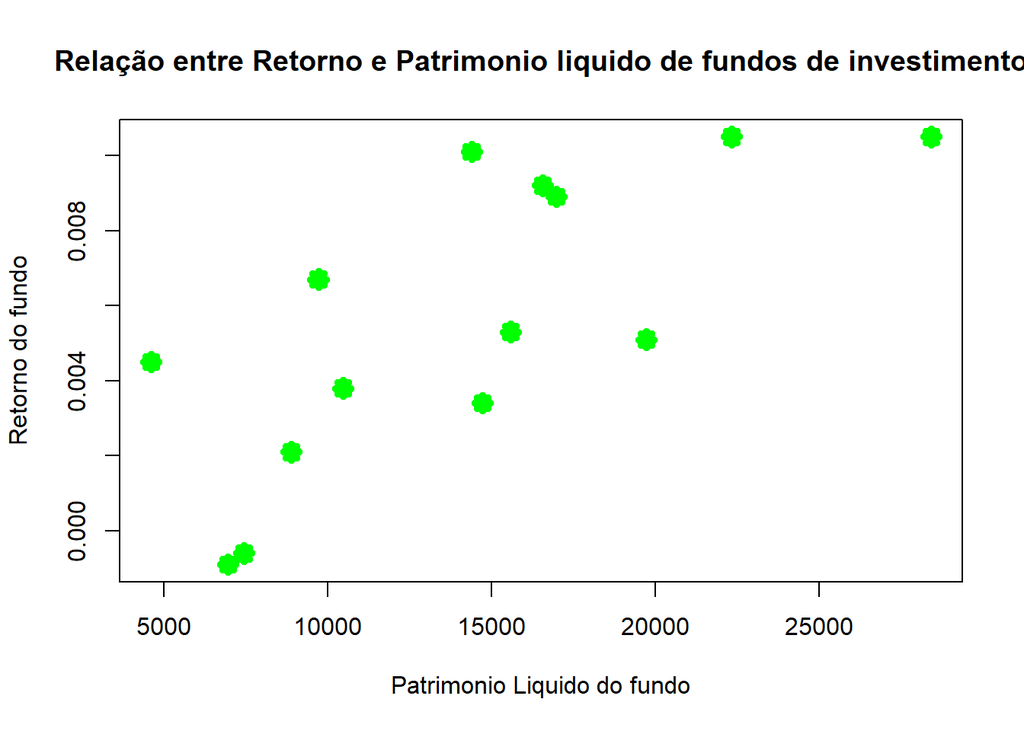

```r
plot(dados$`PL em milhoes`, dados$Retorno,
     pch  = 8,
     col  = "green",
     lwd  = 5,
     main = "Relação entre Retorno e Patrimonio liquido de fundos de investimento",
     xlab = "Patrimonio Liquido do fundo",
     ylab = "Retorno do fundo")
```

## Questão 2:

Crie 6 vetores 2x1 contendo informações sobre média, mediana, mínimo, máximo, variância o desvio padrão do PL e Ret. E seguida, compile os vetores em uma única tabela utilizando o comando cbind.data.frame.

```r
media <- c(mean(dados$`PL em milhoes`),mean(dados$Retorno))
mediana <- c(median(dados$`PL em milhoes`),median(dados$Retorno))
minimo <- c(min(dados$`PL em milhoes`),min(dados$Retorno))
maximo <- c(max(dados$`PL em milhoes`),max(dados$Retorno))
desvio_padrao <- c(sd(dados$`PL em milhoes`),sd(dados$Retorno))
variancia <- c(var(dados$`PL em milhoes`),var(dados$Retorno))
enriched_data <- cbind.data.frame(media,mediana,minimo,maximo, desvio_padrao,variancia)
round_df(enriched_data,5)
```

```
##         media    mediana    minimo     maximo desvio_padrao      variancia
## 1 14049.57143 14550.5000 4600.0000 28409.0000    6600.05778 43560762.72527
## 2     0.00561     0.0052   -0.0009     0.0105       0.00388        0.00002
```

## Questão 3:

A covariância e correlação entre PL e Ret

```r
covariancia <- cov(dados$`PL em milhoes`,dados$Retorno)
correlacao <- cor(dados$`PL em milhoes`,dados$Retorno)
paste("Covariancia:",covariancia)
```

```
## [1] "Covariancia: 18.7401065934066"
```

```r
paste("Correlacao:",correlacao)
```

```
## [1] "Correlacao: 0.731445452727907"
```

## Questão 4:

Crie um modelo linear para captar a relação entre Ret e PL. Reti = A + BPLi + Ei

```r
x <- dados$`PL em milhoes`
y <- dados$Retorno
reg <- lm(y ~ x)
```

## Questão 5:

Insira no gráfico de dispersão anterior uma linha que representa o modelo linear na cor azul.

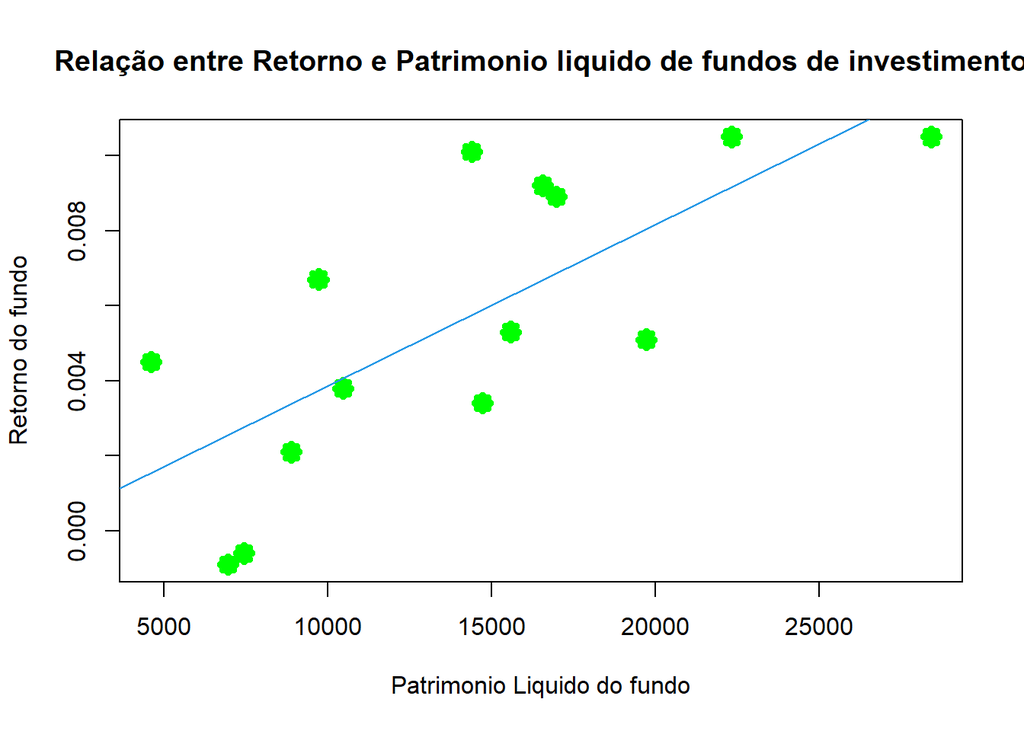

```r
#Grafico Anterior:
plot(dados$`PL em milhoes`, dados$Retorno,
     pch  = 8,
     col  = "green",
     lwd  = 5,
     main = "Relação entre Retorno e Patrimonio liquido de fundos de investimento",
     xlab = "Patrimonio Liquido do fundo",
     ylab = "Retorno do fundo")
#Linha Azul:
abline(reg, col=4)
```

## Questão 6:

Mostre o resultado do modelo e a adequabilidade da modelagem.

```
## [1] "Coeficiente do intercepto: -0.000429925858032385"
```

```
## [1] "Coeficiente do X: 0.00000043020611717924"
```

O resultado do modelo são os coeficientes citados a cima

```r
reg_slm <- summary(reg)
paste("P valor do intercepto=",reg_slm$coefficients[1,4])
```

```
## [1] "P valor do intercepto= 0.813787589294106"
```

```r
paste("P valor do Coeficiente=",reg_slm$coefficients[2,4])
```

```
## [1] "P valor do Coeficiente= 0.00294942039128462"
```

A adequabilidade não é das melhores, o P valor do intercepto é alto, fazendo assim ter grandes chances de fazer parte de um resultado nulo, já o do coeficiente tem sua importancia

## Questão 7

Analise o poder explicativo do modelo.

```
## [1] "R2 do modelo = 0.535012450316333"
```

O poder explicativo do modelo é 53,5% o R², ou seja, 53,5% dos resultados dos fundos podem ser explicados pelo fator PL, uma chance consideravel para um modelo de apenas uma variavel

## Questão 8

Analise o significado do valor e significância de 𝛼 e 𝛽 gerados a um nível de significância de 5%

```r
paste("P valor do intercepto=",reg_slm$coefficients[1,4])
```

```
## [1] "P valor do intercepto= 0.813787589294106"
```

```r
paste("P valor do Coeficiente=",reg_slm$coefficients[2,4])
```

```
## [1] "P valor do Coeficiente= 0.00294942039128462"
```

O p valor do intercepto é maior que 5% por isso faz a variavel ser pouco efetiva ao modelo tendo alta chance de fazer parte de uma hipotese nula,já o p valor do coeficiente é menor que 5%, por isso é significante

## Questão 9

Crie uma expectativa de Ret para um fundo com PL igual a R$7.800,00.

```r
result <- reg_slm$coefficients[1,1] + reg_slm$coefficients[2,1] * 7800
paste("Retorno esperado= ",round(result * 100,3),"%",sep="")
```

```
## [1] "Retorno esperado= 0.293%"
```

## Questão 10

Faça uma nova estimação considerando agora um modelo sem intercepto (𝛼 = 0).

```r
x <- dados$`PL em milhoes`
y <- dados$Retorno
regSemAlfa <- lm(y ~ x - 1)
```

## Questão 11

Insira no gráfico de dispersão a reta deste novo modelo na cor vermelha.

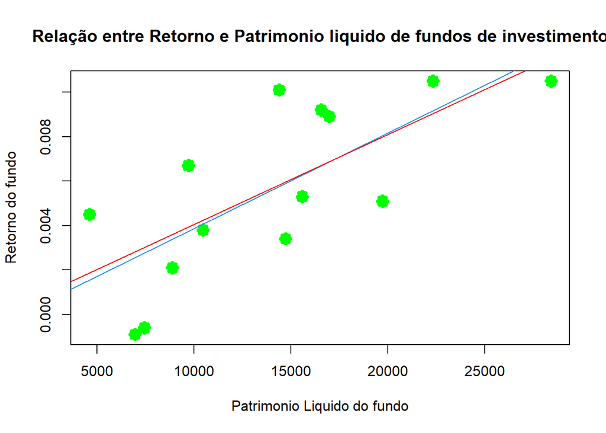

```r
#Grafico Anterior:
plot(dados$`PL em milhoes`, dados$Retorno,
     pch  = 8,
     col  = "green",
     lwd  = 5,
     main = "Relação entre Retorno e Patrimonio liquido de fundos de investimento",
     xlab = "Patrimonio Liquido do fundo",
     ylab = "Retorno do fundo")
#Linha Azul:
abline(reg, col=4)

#Linha vermelha nova:
abline(regSemAlfa, col="red")
```

## Questão 12

Analise a validade do modelo, poder explicativo do modelo e a magnitude e significância do B

```r
regSemAlfa_slm <- summary(regSemAlfa)
paste("R2 do novo modelo=",regSemAlfa_slm$r.squared)
```

```
## [1] "R2 do novo modelo= 0.856351702042533"
```

```r
paste("P valor do novo modelo=",glance(regSemAlfa)$p.value)
```

```
## [1] "P valor do novo modelo= NA"
```

```r
paste("P valor do novo X=",regSemAlfa_slm$coefficients[,4])
```

```
## [1] "P valor do novo X= 0.00000077269311622811"
```

## Questão 13

Compare os resultados dos dois modelos e justifique em termos estatísticos qual dos dois modelos é mais adequado.

```r
paste("R2 do novo modelo=",regSemAlfa_slm$r.squared)
```

```
## [1] "R2 do novo modelo= 0.856351702042533"
```

```r
paste("P valor do novo modelo=",glance(regSemAlfa)$p.value)
```

```
## [1] "P valor do novo modelo= NA"
```

```r
paste("R2 do antigo modelo=",reg_slm$r.squared)
```

```
## [1] "R2 do antigo modelo= 0.535012450316333"
```

```r
paste("P valor do Antigo modelo=",glance(reg)$p.value)
```

```
## [1] "P valor do Antigo modelo= 0.00294942039128463"
```

```r
paste("Melhoria do R2 = ", (regSemAlfa_slm$r.squared - reg_slm$r.squared)/ reg_slm$r.squared *100, "%", sep="")
```

```
## [1] "Melhoria do R2 = 60.0620137972871%"
```

## Questão 14

Responda a seu cliente qual a melhor opção de fundo para investir, os menores ou os maiores

Mesmo com a regressão mais fraca, já demonstrava uma tendencia de fundos com patrimonios maiores terem mais retorno. Com a regressão mais adequada a tendencia foi confirmada, segundo o coeficiente de X:

```r
paste("Coeficiente de x", regSemAlfa_slm$coefficients[1])
```

```
## [1] "Coeficiente de x 0.000000404809713165322"
```

a cada variação de 1 milhão de PL do fundo, o rendimento tende a esse coeficiente maior, alem do mais a relação é positiva, ou seja, um aumenta, o outro tambem.

## Questão 15:

Por fim, levante hipóteses sobre outros fatores que podem impactar o ret de fundos de investimentos.

Levando em consideração o artigo: [IMPACTO DA RELAÇÃO ENTRE TAXAS DE ADMINISTRAÇÃO E O TAMANHO DO FUNDO NA PERFORMANCE FUTURA DOS FUNDOS DE INVESTIMENTO](https://convibra.org/congresso/res/uploads/pdf/artigo23093_20201802.pdf) O *Patrimonio Liquido logaritimizado* apresenta uma *relação negativa*, juntamente com a *Taxa de administração* e a *Idade do fundo*, já por outro lado, apresentam uma *relação positiva* as variaveis *Taxa de performance* a *Taxa de administração ao quadrado*